# lab-01-underwater

Due 2/17/20 at 11:59pm

R is the name of the programming language itself and RStudio is a convenient interface.

The goals of this lab are two-fold. First, I want to make sure that you are comfortable with the R and RStudio environment. Second, I want everyone to make some plots using `ggplot`. Be sure that you read Chapter 3 of our textbook. I’ve also added links to other resources, both in our slides and on Moodle.

As the labs progress, you are encouraged to explore beyond what the labs dictate; a willingness to experiment will make you a much better programmer. Before we get to that stage, however, you need to build some basic fluency in R. Today we begin with the fundamental building blocks of R and RStudio: the interface, reading in data, and basic plots.

You may talk to and share code with your lab group members for this exercise, but I would like for everyone to turn in their work. **Please do not work with anyone outside of your group.**

# Setting Up Our R Environment

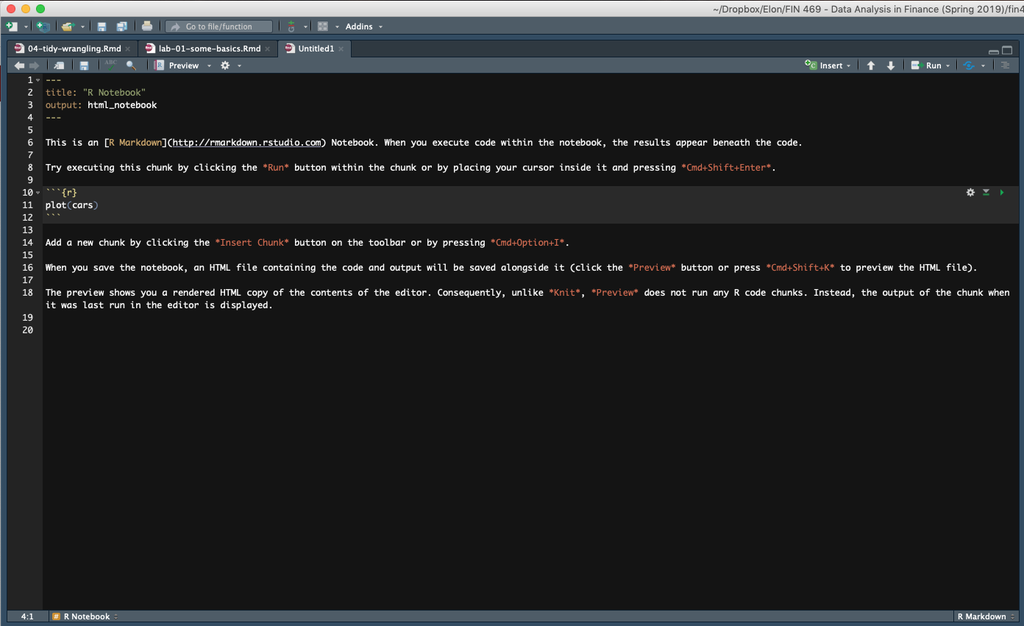

The top portion of your R Markdown file (between the three dashed lines) is called the YAML. It stands for “YAML Ain’t Markup Language”. It is a human friendly data serialization standard for all programming languages. All you need to know is that this area is called the YAML and that it contains meta information about your document.

Start by opening the project for this course in RStudio. Then, go to the project folder that you created for this course. If you do not have a project folder or a project for the course, see Chapter 8 of our text.

Create a folder called `labs`. Then, inside this folder, create a folder called `lab1`. Inside of `lab1`, create a folder called `data`. Then, use RStudio to create a new **R Notebook** inside of the `lab1` folder. Remember, an R Notebook is where you can mix your R code and written text. You format that text using the markdown syntax. Take a look at the Lecture 1 materials for examples of R Markdown syntax. Currently, your new notebook is called *Untitled1*. Save your notebook as “lab-01-underwater” in your `lab1` folder.

The code is generated when creating a new R Notebook is there to provide some syntax guidance.

In the YAML header, add lines for `author:` and `date:` underneath `title:`. Put your name for author and today’s date. Then, hit the `preview` button.

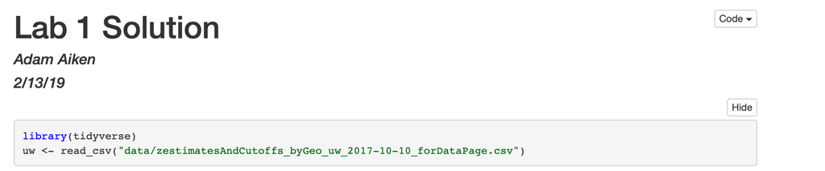

My first preview with title, author, and date. Of course, I have a different title than you!

If you look in the folder that contains `lab-01-underwater.rmd`, the R Markdown file you are coding in, you’ll now see a file called `lab-01-underwater.nb.html`. This is the HTML notebook file that gets generated when you do a preview. **This is the file that I would like you to turn in via Moodle when you’re done.**

## Installing and Loading Packages

In this lab, we will work with the `tidyverse` packages, a collection of packages for doing data analysis in a “tidy” way. In particular, we will make use of `ggplot2` and just two pieces of `dplyr`. We are also going to use the `here` package to navigate folders when loading in our data.

Install these packages by running the following in the console. No need to put this in your R Notebook document. If you’ve already installed the `tidyverse` and `here`, then you can skip this step.

```r
install.packages("tidyverse")
install.packages("here")
```

Now, let’s get started with some code in the R Notebook. Go ahead and delete the code below the YAML header that you get everytime you create a new R Notebook. Then, insert a new R chunk. You can name each chunk and put some options in between the curly brackets. The top line of your R chunk should look like `` ```{r set-up} ``. I like to call my first chunk **set-up** and then put things like my `library()` statements in there. Add code to load the `tidyverse` and `here` libraries. Remember, you need to do this in every R Notebook where you want to use something from the `tidyverse`. As you write more code, your set-up chunk will include more things.

I left the name of the file the way it was when downloaded for a reason. If you change your file names, you won’t be able to trace back your raw data to the source. You can read more about Zillow’s research [in this NPR interview](https://www.npr.org/2018/06/18/620939197/zillow-data-used-to-project-impact-of-sea-level-rise-on-real-estate).

```r
library(tidyverse)
uw <- read_csv(here::here("labs", "lab1", "data",
                          "zestimatesAndCutoffs_byGeo_uw_2017-10-10_forDataPage.csv"))
```

Make sure that you’ve run the code chunk that loads the `tidyverse` library and brings in our data. Do you see the cryptic message underneath? That will appear in your document if you don’t get rid of *messages*. This is an option for that you can add to each code chunk that you create. Go back and change the top line in that code chunk to read `` ```{r set-up, echo=TRUE, message=FALSE} ``

This means that the code will go into your document, but the messages R gives you about what happened will not. Any output, like plots, will still appear, however.

**Finally, remember to re-run your chunks everytime you change part of it. The output won’t appear in the HTML file unless you’ve run the chunk yourself. They same is true if you change an input into a chunk in another chunk. Run your chunks!**

# Data

You can find many different Zillow data sets [here](https://www.zillow.com/research/data/). The “uw” here stands for “under water” in a very literal sense. I first thought they were talking about mortgages!

The data frame we will be working with today contains data from [Zillow.com](https://www.zillow.com), the housing web site, on the number of homes, the median value of homes, etc. at-risk for flooding due to rising sea levels.

Let’s take a `glimpse` at our data. The `glimpse` function comes from the `tibble` package. I am using the `package::function` method here, just to make it clear where `glimpse` is coming from. You can’t run `glimpse` without the `tibble` package installed. You get `tibble` as part of the `tidyverse`.

```r
tibble::glimpse(uw)
```

```
## Observations: 2,610
## Variables: 24
## $ RegionType                   <chr> "Nation", "State", "State", "State", "St…
## $ RegionName                   <chr> "United States", "Alabama", "California"…
## $ StateName                    <chr> NA, "Alabama", "California", "Connecticu…
## $ MSAName                      <chr> NA, NA, NA, NA, NA, NA, NA, NA, NA, NA, …
## $ AllHomes_Tier1               <dbl> 35461549, 546670, 3060171, 333904, 10298…
## $ AllHomes_Tier2               <dbl> 35452941, 520247, 3076238, 334688, 12757…
## $ AllHomes_Tier3               <dbl> 35484532, 491300, 3169584, 336254, 12798…
## $ AllHomes_AllTiers            <dbl> 106399022, 1558217, 9305993, 1004846, 35…
## $ UWHomes_Tier1                <dbl> 594672, 2890, 8090, 4434, 4105, 313090, …
## $ UWHomes_Tier2                <dbl> 542681, 2766, 14266, 3807, 2574, 263276,…
## $ UWHomes_Tier3                <dbl> 725955, 5046, 17783, 7289, 3286, 331817,…
## $ UWHomes_AllTiers             <dbl> 1863308, 10702, 40139, 15530, 9965, 9081…
## $ UWHomes_TotalValue_Tier1     <dbl> 122992000000, 365986699, 4859725390, 102…
## $ UWHomes_TotalValue_Tier2     <dbl> 195513000000, 629176919, 12969249624, 18…
## $ UWHomes_TotalValue_Tier3     <dbl> 597449000000, 2583039495, 26666381753, 8…
## $ UWHomes_TotalValue_AllTiers  <dbl> 915954000000, 3578203113, 44495356767, 1…
## $ UWHomes_MedianValue_AllTiers <dbl> 310306.0, 270254.0, 860373.0, 442036.0, …
## $ AllHomes_Tier1_ShareUW       <dbl> 0.016769487, 0.005286553, 0.002643643, 0…
## $ AllHomes_Tier2_ShareUW       <dbl> 0.015307080, 0.005316705, 0.004637483, 0…
## $ AllHomes_Tier3_ShareUW       <dbl> 0.020458351, 0.010270710, 0.005610515, 0…
## $ AllHomes_AllTiers_ShareUW    <dbl> 0.017512454, 0.006868106, 0.004313242, 0…
## $ UWHomes_ShareInTier1         <dbl> 0.3191485, 0.2700430, 0.2015496, 0.28551…
## $ UWHomes_ShareInTier2         <dbl> 0.2912460, 0.2584564, 0.3554149, 0.24513…
## $ UWHomes_ShareInTier3         <dbl> 0.3896055, 0.4715007, 0.4430355, 0.46934…
```

The first thing to note about this data is that there are several tiers. Some numbers are at the national level, some at the region, some at the state, and some at the MSA. As we’ll see throughout the semester, “tidydata” refers to one row, one observation, across different variables (columns) and, possibly, across time. When you have multiple observations of the same firm, state, person, etc. over time, we call that “panel data”. Panel data is `tidy` too.

This data isn’t really tidy. Note that some RegionTypes (e.g. Nation, State) are actually summaries of other rows. This is bit confusing, but we will work with it as is.

MSA stands for *Metropolitan Statistical Area*. Finally, let’s think about the variable definitions a bit. Zillow places homes into three tiers based on the home’s estimated market value, with *Tier3* being the highest value. *AllHomes* refers to all homes in that tier or across all tiers. *UWHomes* refers to homes that are at risk for flooding. Note that there are some variables that are counts, some that are dollar values, and others that are percentages.

# Data visualization and summary

With your data loaded and an R Markdown notebook ready to go, please answer the following questions. Include all of your R code and output in the final R Notebook. Any written responses should go along with your R code and output and be nicely formatted using R Markdown. **I only want to receive one file from you - the nb.html document.**

See Chapter 5 or our slides for how to use `filter` and `%>%`. This is the only `dplyr` that you need for this exercise.

1. Start with the full set of data and use `filter` and `%>%` to keep only the `RegionType` observations that are equal to “MSA”. Then, create a scatter plot of `UWHomes_Tier1` on the x axis and `UWHomes_TotalValue_Tier1` on the y. Do all of this in one R chunk. You will then run that code together in the chunk in your notebook. The resulting plot should appear below.

How would you create a **new** data set with just the MSA `RegionType` observations? If you do that, you won’t need to do the `filter` and `%>%` each time.

**An important note**: You’ll note that sometimes people put the `mapping = aes()` inside of `ggplot()` and other times they put it inside of the `geom_()` statement. Our textbook tends to put them inside of the `geom_x()` statement. `ggplot()` gets a `data =`. See Section 3.2.3 of our text. But, when you are using pipes, you don’t need the `data =` inside `ggplot()`. The data gets “passed through” the pipe.

You can put `mapping = aes()` inside the `geom_x()` with other options following after a comma, like in the textbook. You could also put `mapping = aes()` inside `ggplot()` to follow the notes.

It is important to get use to seeing the same thing done several ways. There’s never just one way to code something. This will become very clear when you search for help online.

2. That looks OK, I guess. Go back and add some appropriate labels for the X and Y axis. Give your chart a title. Check out the `xlab`, `ylab`, and `ggtitle` options. Finally, use `geom_smooth` to add a linear trend line. You can do all of this in the original chunk. No need to write the same code again.
3. Is there anything particularily surprising here?
4. Let’s create a statistical summary of sorts for each state. Again use `filter` and `%>%` to keep only the MSA observations, unless you created a new data set with just those observations, as mentioned above. Use `geom_boxplot()` to summarise `UWHomes_Tier1` by state across all MSA (there are multiple MSA observations per state). Again, add appropriate labeling. Anything interesting here?

Tip: For Exercise 4, to make things easy to read, put the state name on the y axis. How can you do this?

5. Anything change when you create the same plot for `UWHomes_Tier3`? Which states should be worried, assuming that we like Zillow’s model? Finally, add `geom_jitter()` to the new Tier3 graph. What does this do?
6. Create a histogram that shows the distribution of `UWHomes_Tier3` across all MSA regions. Use a `binwidth` of 5000 homes. Is that a normal distribution? Why or why not?

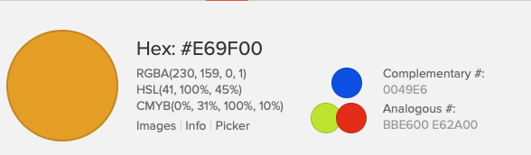

7. Create two denisty plots on the same graph that compare the distribution of `UWHomes_Tier3` across all MSAs in just CA and NJ. Use `scale_fill_manual` to make California this particular grey (“#999999”) and New Jersey this specific orange (“#E69F00”).

# Other Items

- **Resize your figures:**

Click on the gear icon in on top of the R Markdown document, and select “Output Options…” in the dropdown menu. In the pop up dialogue box go to the Figures tab and change the height and width of the figures, and hit OK when done. Then, `preview` your document and see how you like the new sizes. Change and `preview` again and again until you’re happy with the figure sizes. Note that these values get saved in the YAML at the top of your Notebook.

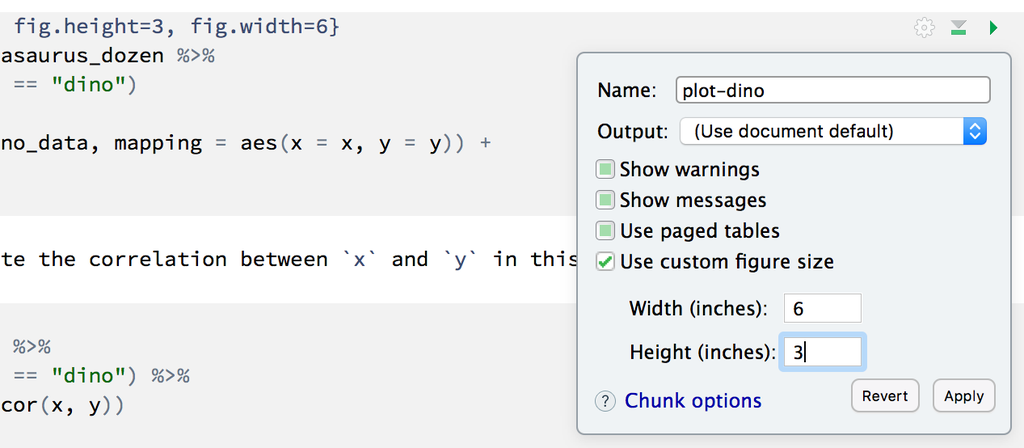

You can also use different figure sizes for different figures. To do so click on the gear icon within the chunk where you want to make a change. Changing the figure sizes added new options to these chunks: `fig.width` and `fig.height`. You can change them by defining different values directly in your R Markdown document as well.

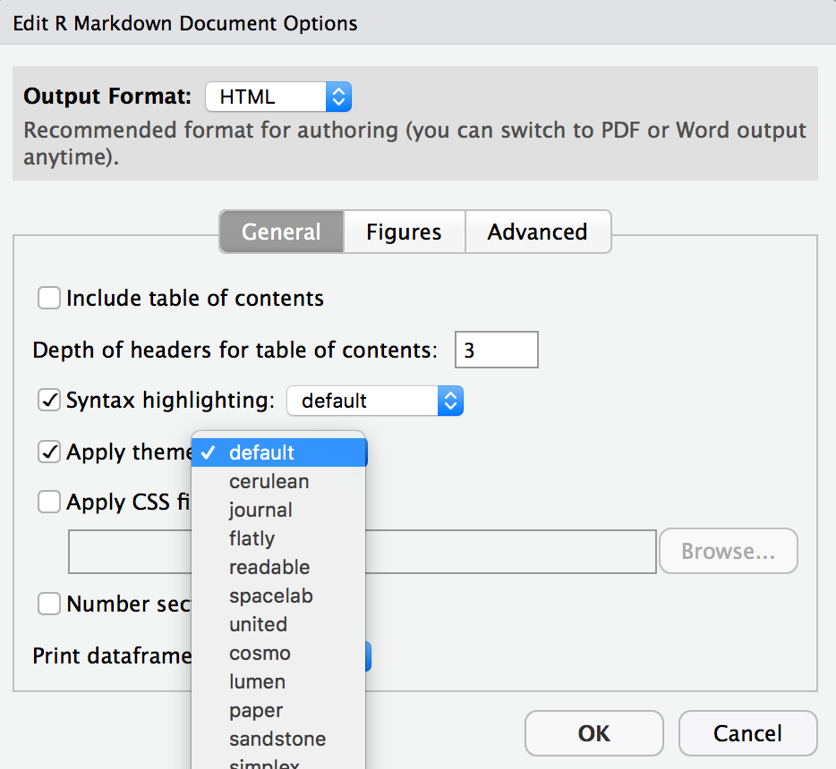

- **Change the look of your report:**

Once again click on the gear icon at the top of the R Markdown document and select “Output Options…” in the dropdown menu. In the General tab of the pop up dialogue box, try out different Syntax highlighting and theme options. Hit OK and `preview` your document to see how it looks. Play around with these until you’re happy with the look.

- **Remember to run your chunks!**

Getting weird output in your final document? Did you remember to add `message=FALSE` to your R chunk options?

The output in your final document will only reflect the last run for each chunk. Note that there is an option to run all chunks above or below your cursor under the Run menu.

# You are done!

Submit your individual work via Moodle.